# Lanzarote Soil statistical exploration

Yago Sánchez Gancedo

## 1. Introduction of the data

The first task is to read the data in R

```r
install.packages("openxlsx", repos = "http://cran.us.r-project.org")
library(openxlsx)

#Creating the local path to the data, and using that path to generate an object containing such data

DataPath <- "/Users/cacharra2.0/Desktop/TFM/Lanzarotesoil.xlsx"
 SoilData <- read.xlsx(DataPath, colNames = TRUE)
```

## 2. Superficial exploration of the data

Once the data is stored in the variable “SoilData”, a brief superficial exploration can be performed to ensure that everything is correct and that the data is treated accordingly:

Visualization of the first and last subset of data, to check if it matches with the original data table.

```r
head(SoilData)
```

```
##   SAMPLE SAMPLE.NUMBER                    CLASS SUBCLASS1_AGRICULTURALSYSTEM
## 1     T2             1 natural soil nonterraced                   Non-Farmed
## 2     T4             2 natural soil nonterraced                   Non-Farmed
## 3     T6             3 natural soil nonterraced                   Non-Farmed
## 4     T8             4 natural soil nonterraced                   Non-Farmed
## 5    T10             5 natural soil nonterraced                   Non-Farmed
## 6    T12             6 natural soil nonterraced                   Non-Farmed
##   SUBCLASS2_FARMED  SUBCLASS3_MULCHING     SUBCLASS4_IRRIGATION
## 1       Non-Farmed No mulch non-farmed No Irrigation non-farmed
## 2       Non-Farmed No mulch non-farmed No Irrigation non-farmed
## 3       Non-Farmed No mulch non-farmed No Irrigation non-farmed
## 4       Non-Farmed No mulch non-farmed No Irrigation non-farmed
## 5       Non-Farmed No mulch non-farmed No Irrigation non-farmed
## 6       Non-Farmed No mulch non-farmed No Irrigation non-farmed
##    SUBCLASS5_POSITION CLASS.REFERENCE   XUTM    YUTM DEPTH TEXTURE  EC  PH
```

[output cut: 27 more lines]

```r
tail(SoilData)
```

```
##     SAMPLE SAMPLE.NUMBER                      CLASS
## 610    L89           620 natural soil nonfarmed III
## 611    L90           621 natural soil nonfarmed III
## 612    L95           622 natural soil nonfarmed III
## 613    L97           624 natural soil nonfarmed III
## 614    L98           625 natural soil nonfarmed III
## 615    L99           626 natural soil nonfarmed III
##     SUBCLASS1_AGRICULTURALSYSTEM SUBCLASS2_FARMED  SUBCLASS3_MULCHING
## 610                   Non-Farmed       Non-Farmed No mulch non-farmed
## 611                   Non-Farmed       Non-Farmed No mulch non-farmed
## 612                   Non-Farmed       Non-Farmed No mulch non-farmed
## 613                   Non-Farmed       Non-Farmed No mulch non-farmed
## 614                   Non-Farmed       Non-Farmed No mulch non-farmed
## 615                   Non-Farmed       Non-Farmed No mulch non-farmed
##         SUBCLASS4_IRRIGATION  SUBCLASS5_POSITION CLASS.REFERENCE   XUTM    YUTM
```

[output cut: 27 more lines]

Structure of the data.

```r
dim(SoilData)
```

```
## [1] 615  39
```

```r
ncol(SoilData)
```

```
## [1] 39
```

```r
nrow(SoilData)
```

```
## [1] 615
```

```r
str(SoilData)
```

```
## 'data.frame':    615 obs. of  39 variables:
##  $ SAMPLE                      : chr  "T2" "T4" "T6" "T8" ...
##  $ SAMPLE.NUMBER               : num  1 2 3 4 5 6 7 8 9 10 ...
##  $ CLASS                       : chr  "natural soil nonterraced" "natural soil nonterraced" "natural soil nonterraced" "natural soil nonterraced" ...
##  $ SUBCLASS1_AGRICULTURALSYSTEM: chr  "Non-Farmed" "Non-Farmed" "Non-Farmed" "Non-Farmed" ...
##  $ SUBCLASS2_FARMED            : chr  "Non-Farmed" "Non-Farmed" "Non-Farmed" "Non-Farmed" ...
##  $ SUBCLASS3_MULCHING          : chr  "No mulch non-farmed" "No mulch non-farmed" "No mulch non-farmed" "No mulch non-farmed" ...
##  $ SUBCLASS4_IRRIGATION        : chr  "No Irrigation non-farmed" "No Irrigation non-farmed" "No Irrigation non-farmed" "No Irrigation non-farmed" ...
##  $ SUBCLASS5_POSITION          : chr  "Mountain non-farmed" "Mountain non-farmed" "Mountain non-farmed" "Mountain non-farmed" ...
##  $ CLASS.REFERENCE             : chr  "A" "A" "A" "A" ...
##  $ XUTM                        : num  642278 640880 643509 643686 641485 ...
##  $ YUTM                        : num  3221052 3217980 3218903 3219321 3221154 ...
##  $ DEPTH                       : num  1 1 4 2 2 2 2 4 4 1 ...
##  $ TEXTURE                     : num  4 2 2 2 1 4 1 2 2 4 ...
##  $ EC                          : num  0.8 0.8 2.8 1.1 1.2 3.1 0.9 1.4 1.2 0.9 ...
```

[output cut: 25 more lines]

A summary to see if the variables are treated with the correct format

```r
summary(SoilData)
```

```
##     SAMPLE          SAMPLE.NUMBER      CLASS
##  Length:615         Min.   :  1.0   Length:615
##  Class :character   1st Qu.:154.5   Class :character
##  Mode  :character   Median :308.0   Mode  :character
##                     Mean   :308.9
##                     3rd Qu.:461.5
##                     Max.   :626.0
##
##  SUBCLASS1_AGRICULTURALSYSTEM SUBCLASS2_FARMED   SUBCLASS3_MULCHING
##  Length:615                   Length:615         Length:615
##  Class :character             Class :character   Class :character
##  Mode  :character             Mode  :character   Mode  :character
##
##
##
##
##  SUBCLASS4_IRRIGATION SUBCLASS5_POSITION CLASS.REFERENCE         XUTM
##  Length:615           Length:615         Length:615         Min.   :609250
##  Class :character     Class :character   Class :character   1st Qu.:630679
##  Mode  :character     Mode  :character   Mode  :character   Median :637771
##                                                             Mean   :637251
##                                                             3rd Qu.:646304
##                                                             Max.   :653197
##
##       YUTM             DEPTH          TEXTURE            EC
##  Min.   :3192823   Min.   :1.000   Min.   :1.000   Min.   :  0.4000
##  1st Qu.:3207726   1st Qu.:1.000   1st Qu.:2.000   1st Qu.:  0.8452
##  Median :3215831   Median :2.000   Median :3.000   Median :  1.4000
##  Mean   :3215020   Mean   :2.161   Mean   :2.742   Mean   : 11.3277
##  3rd Qu.:3221146   3rd Qu.:3.000   3rd Qu.:4.000   3rd Qu.:  5.4225
##  Max.   :3237176   Max.   :4.000   Max.   :4.000   Max.   :159.6000
##                    NA's   :212     NA's   :84      NA's   :1
##        PH           PHwater          SAR               Caexch
##  Min.   :6.500   Min.   :5.90   Min.   :  0.7425   Min.   : 0.20
##  1st Qu.:7.700   1st Qu.:9.00   1st Qu.:  3.4000   1st Qu.:12.34
##  Median :8.100   Median :9.10   Median :  5.8000   Median :15.60
##  Mean   :8.014   Mean   :9.11   Mean   : 15.3280   Mean   :16.00
##  3rd Qu.:8.300   3rd Qu.:9.30   3rd Qu.: 11.2750   3rd Qu.:19.20
##  Max.   :9.115   Max.   :9.90   Max.   :347.3112   Max.   :54.00
##  NA's   :1       NA's   :176    NA's   :85         NA's   :88
```

[output cut: 33 more lines]

```
##  Min.   :  0.0   Min.   : 13.68   Min.   :100.4   Min.   : 0.0218
##  1st Qu.:231.7   1st Qu.:168.00   1st Qu.:130.7   1st Qu.: 1.4180
##  Median :326.5   Median :300.26   Median :146.2   Median : 3.2037
##  Mean   :316.8   Mean   :348.69   Mean   :145.6   Mean   : 6.1191
##  3rd Qu.:404.2   3rd Qu.:487.23   3rd Qu.:160.1   3rd Qu.: 8.9221
##  Max.   :675.9   Max.   :986.76   Max.   :197.9   Max.   :31.6929
##  NA's   :339     NA's   :339      NA's   :372     NA's   :372
##      ELEVAT
##  Min.   :  6.399
##  1st Qu.:104.296
##  Median :189.816
##  Mean   :189.055
##  3rd Qu.:249.940
##  Max.   :517.500
##  NA's   :372
```

As it can be seen with the two previous commands, some variables are not treated as desired. A correction is needed:

```r
SoilData$SAMPLE.NUMBER <- as.character(SoilData$SAMPLE.NUMBER)
SoilData$CLASS <- factor(SoilData$CLASS)
SoilData$SUBCLASS1_AGRICULTURALSYSTEM <- factor(SoilData$SUBCLASS1_AGRICULTURALSYSTEM )
SoilData$SUBCLASS2_FARMED <- factor(SoilData$SUBCLASS2_FARMED)
SoilData$SUBCLASS3_MULCHING <- factor(SoilData$SUBCLASS3_MULCHING)
SoilData$SUBCLASS4_IRRIGATION <- factor(SoilData$SUBCLASS4_IRRIGATION)
SoilData$SUBCLASS5_POSITION <- factor(SoilData$SUBCLASS5_POSITION)
SoilData$CLASS.REFERENCE <- factor(SoilData$CLASS.REFERENCE)
SoilData$DEPTH <- factor(SoilData$DEPTH, levels=c(1,2,3,4), labels=c("0-30 cm", "30-60 cm", "60-90 cm", ">90 cm"))
SoilData$TEXTURE <- factor(SoilData$TEXTURE, levels= c(1,2,3,4), labels=c("Arenosa", "Limosa", "Arcillosa", "Franca"))
```

## 3. Wrangling of the data

Creating a new factor with the different pH types, and categories for rainfall, slope and elevation.

```r
SoilData$PHgrouped <- cut(SoilData$PH, breaks=c(-Inf, 6, 8, Inf), labels=c("Acid", "Neutral", "Basic"))

SoilData$rainfallgrouped <- factor(cut(SoilData$RAINFALL_A, breaks=c(-Inf,low_cut_break(SoilData,"RAINFALL_A"), high_cut_break(SoilData,"RAINFALL_A"), Inf), labels=c("local low rainfall", "local medium rainfall", "local high rainfall")))

SoilData$slopegrouped <- factor(cut(SoilData$SLOPE, breaks=c(-Inf,5,15, Inf), labels=c("low slope", "medium slope", "high slope")))

SoilData$elevatgrouped <- factor(cut(SoilData$ELEVAT, breaks=c(-Inf,low_cut_break(SoilData,"ELEVAT"), high_cut_break(SoilData,"ELEVAT"), Inf), labels=c("low elevation", "normal elevation", "high elevation")))
```

## 4. Variable exploration

The function “variable_exploration” is applied to all variables, which generated a pdf file with all the information required.

```r
variable_names <- colnames(SoilData)
for (i in seq_along(variable_names)){
  variable_exploration(SoilData, variable_names[i])
}
```

In the different pdf files that variable_exploration generated, some outliers can be seen in the boxplots. These are removed below manually via the remove_outliers_visually function, so they don’t interfere in the next steps of the analysis.

```r
SoilData <- Remove_outliers_visually(SoilData, "Caexch", 3, 0)
SoilData <-Remove_outliers_visually(SoilData, "CEC", 3, 0)
SoilData <-Remove_outliers_visually(SoilData, "Corg", 2, 0)
SoilData <-Remove_outliers_visually(SoilData, "CU", 2, 0)
#SoilData <-Remove_outliers_visually(SoilData, "EC", 4, 0)
SoilData <-Remove_outliers_visually(SoilData, "FE", 1, 0)
SoilData <-Remove_outliers_visually(SoilData, "HWSB", 3, 0)
#SoilData <-Remove_outliers_visually(SoilData, "Kexch", 1, 0)
SoilData <-Remove_outliers_visually(SoilData, "Mgexch", 1, 0)
SoilData <-Remove_outliers_visually(SoilData, "MN", 2, 0)
SoilData <-Remove_outliers_visually(SoilData, "Naexch", 1, 0)
#SoilData <-Remove_outliers_visually(SoilData, "PH", 0, 3)
SoilData <-Remove_outliers_visually(SoilData, "PHwater", 0, 3)
SoilData <-Remove_outliers_visually(SoilData, "Polsen", 2, 0)
SoilData <-Remove_outliers_visually(SoilData, "SAR", 1, 0)
#SoilData <-Remove_outliers_visually(SoilData, "Silt.g.kg-1", 1, 0)
SoilData <-Remove_outliers_visually(SoilData, "TN", 2, 0)
SoilData <-Remove_outliers_visually(SoilData, "ZN", 2, 0)
```

## 5. Principal component analysis

```r
numeric_variables <- c()
for (i in seq_along(variable_names)){

  variable_name <- variable_names[i]

  if (is.numeric(SoilData[,variable_name])){
    numeric_variables <- c(numeric_variables, variable_name)
  }
}

numeric_SoilData <- dplyr::select(SoilData, (numeric_variables))

#Coordinates variables are also extracted

numeric_SoilData$XUTM <- NULL
numeric_SoilData$YUTM <- NULL

#Subclass variables are added

numeric_SoilData[,"SUBCLASS1_AGRICULTURALSYSTEM"] <- SoilData$SUBCLASS1_AGRICULTURALSYSTEM

numeric_SoilData[,"SUBCLASS2_FARMED"] <- SoilData$SUBCLASS2_FARMED

numeric_SoilData[,"SUBCLASS3_MULCHING"] <- SoilData$SUBCLASS3_MULCHING

numeric_SoilData[,"SUBCLASS4_IRRIGATION"] <- SoilData$SUBCLASS4_IRRIGATION

numeric_SoilData[,"SUBCLASS5_POSITION"] <- SoilData$SUBCLASS5_POSITION
```

The first principal component analysis will be performed with variables with less than 100 NAs??

```r
SoilData_pca1filter <- Remove_NA_lines(SoilData, c(14:33))

SoilData.pca1 <- prcomp(SoilData_pca1filter[,14:33], center=TRUE, scale.=TRUE)
library(ggbiplot)

#PROBAR!! prcomp(~V1+V2, data=d, center = TRUE, scale = TRUE, na.action = na.omit)
```

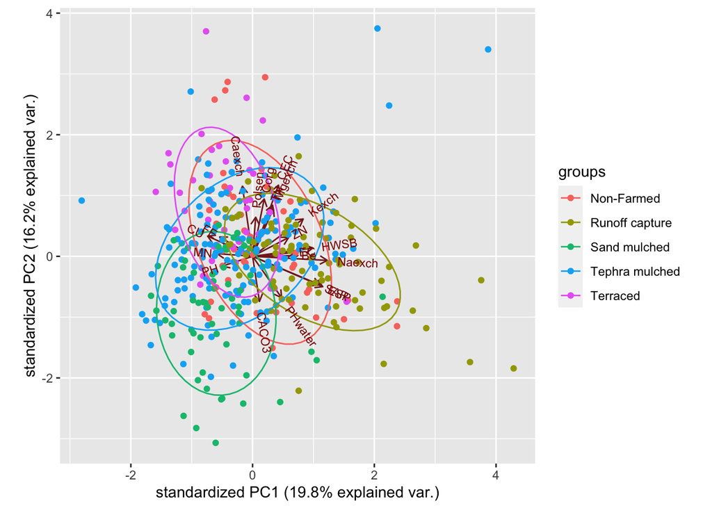

```r
ggbiplot(SoilData.pca1, ellipse=TRUE, groups = SoilData_pca1filter$SUBCLASS1_AGRICULTURALSYSTEM)
```

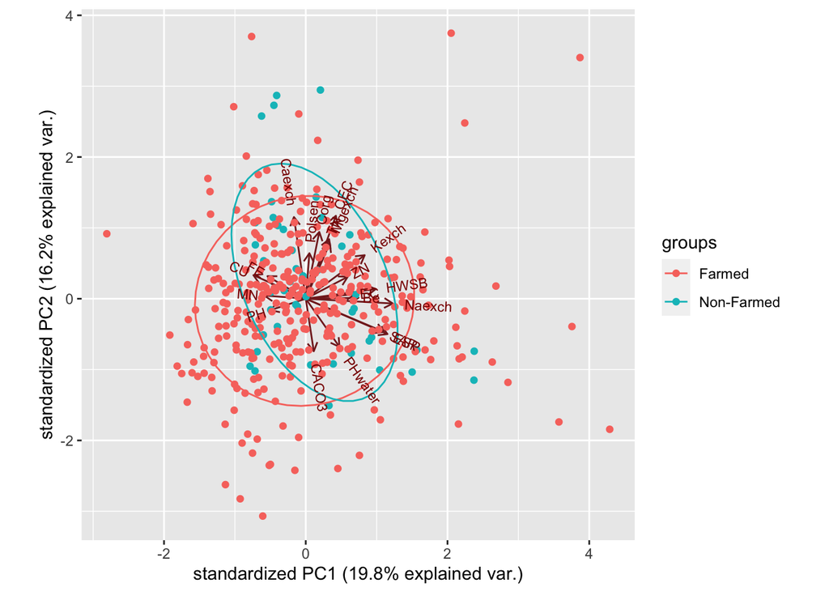

```r
ggbiplot(SoilData.pca1, ellipse=TRUE, groups = SoilData_pca1filter$SUBCLASS2_FARMED)
```

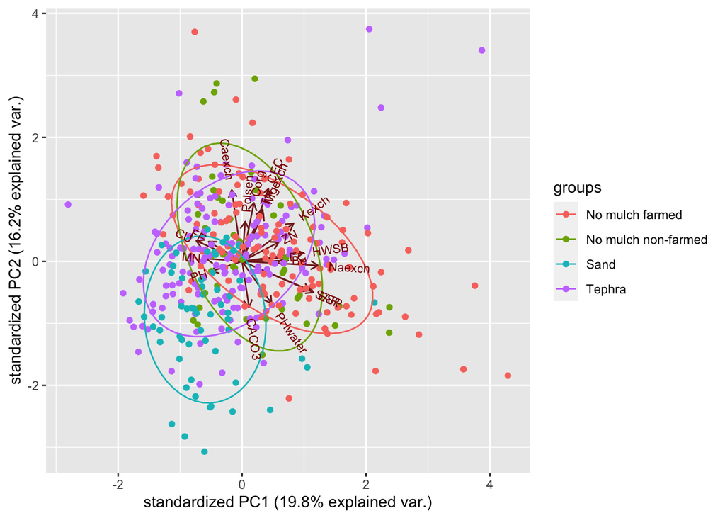

```r
ggbiplot(SoilData.pca1, ellipse=TRUE, groups = SoilData_pca1filter$SUBCLASS3_MULCHING)
```

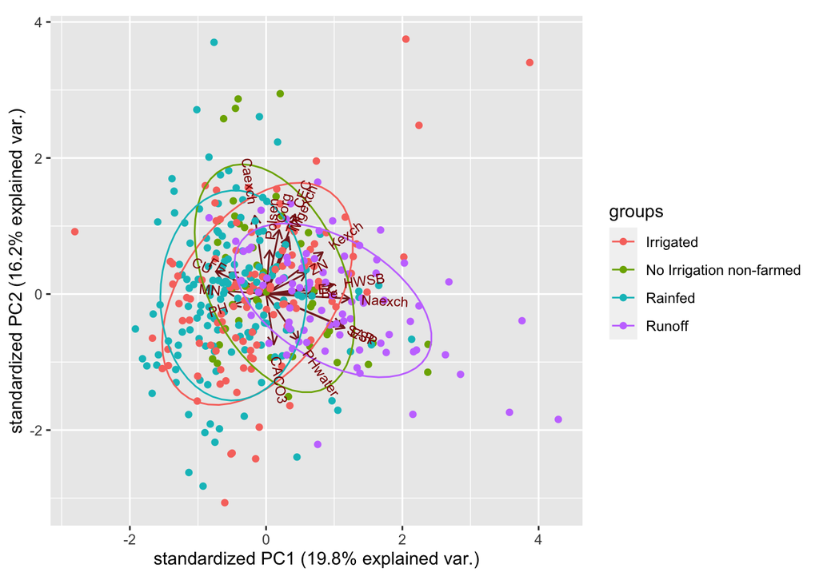

```r
ggbiplot(SoilData.pca1, ellipse=TRUE, groups = SoilData_pca1filter$SUBCLASS4_IRRIGATION)
```

For the PCA grouping by position of the sample (inland, mountain or coastal), the variables PHwater and HWSB (Hot Water Soluble Boro) will not be taken into account as there are too many NAs for the coastal category.

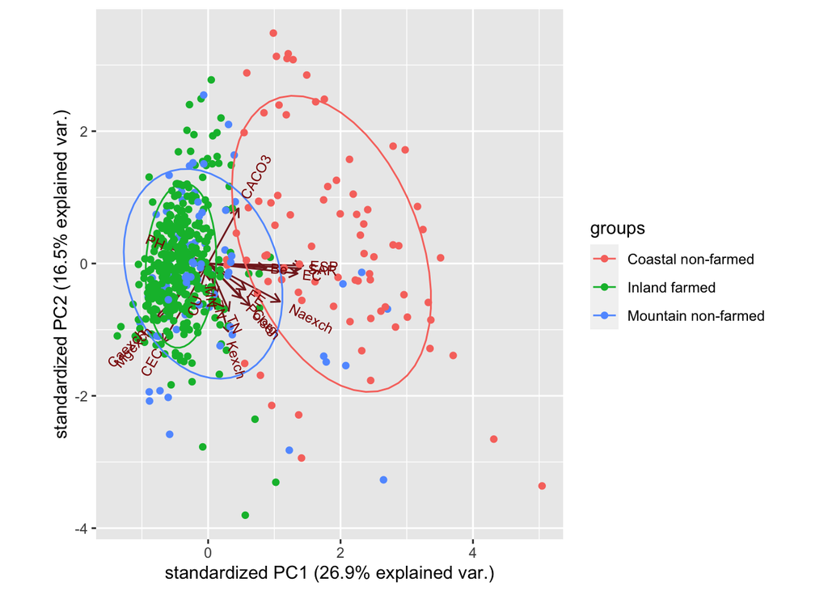

```r
SoilData_pca1filter2 <- Remove_NA_lines(SoilData, c(14,15,17:31,33))

SoilData.pca1position <- prcomp(SoilData_pca1filter2[,c(14,15,17:31,33)], center=TRUE, scale.=TRUE)

ggbiplot(SoilData.pca1position, ellipse=TRUE, groups = SoilData_pca1filter2$SUBCLASS5_POSITION)
```

Below, the PCA is repeated, taking into account all the variables

```r
SoilData_pca1filterall <- Remove_NA_lines(SoilData, c(14:33,37:39))

SoilData.pca2 <- prcomp(SoilData_pca1filterall[,c(14:33,37:39)], center=TRUE, scale.=TRUE)
library(ggbiplot)
```

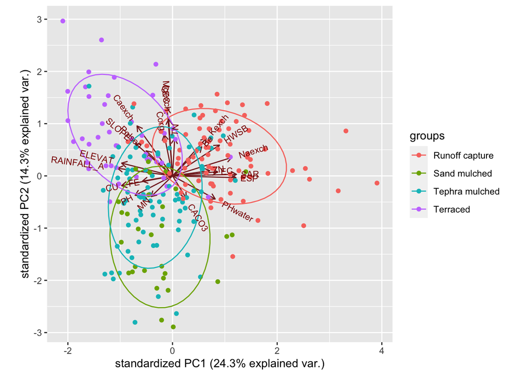

```r
ggbiplot(SoilData.pca2, ellipse=TRUE, groups = SoilData_pca1filterall$SUBCLASS1_AGRICULTURALSYSTEM)
```

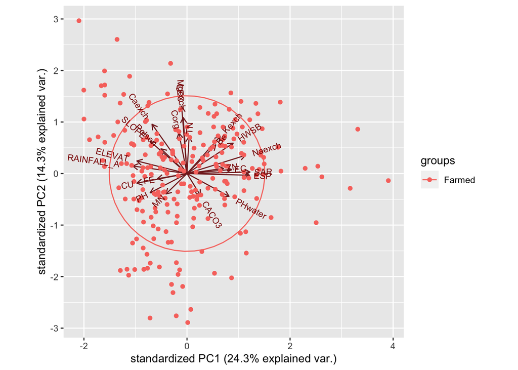

```r
ggbiplot(SoilData.pca2, ellipse=TRUE, groups = SoilData_pca1filterall$SUBCLASS2_FARMED)
```

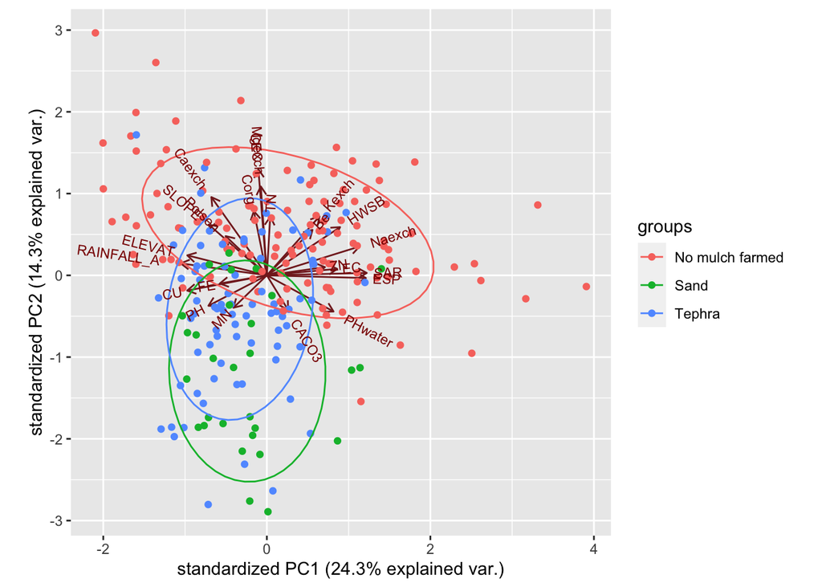

```r
ggbiplot(SoilData.pca2, ellipse=TRUE, groups = SoilData_pca1filterall$SUBCLASS3_MULCHING)
```

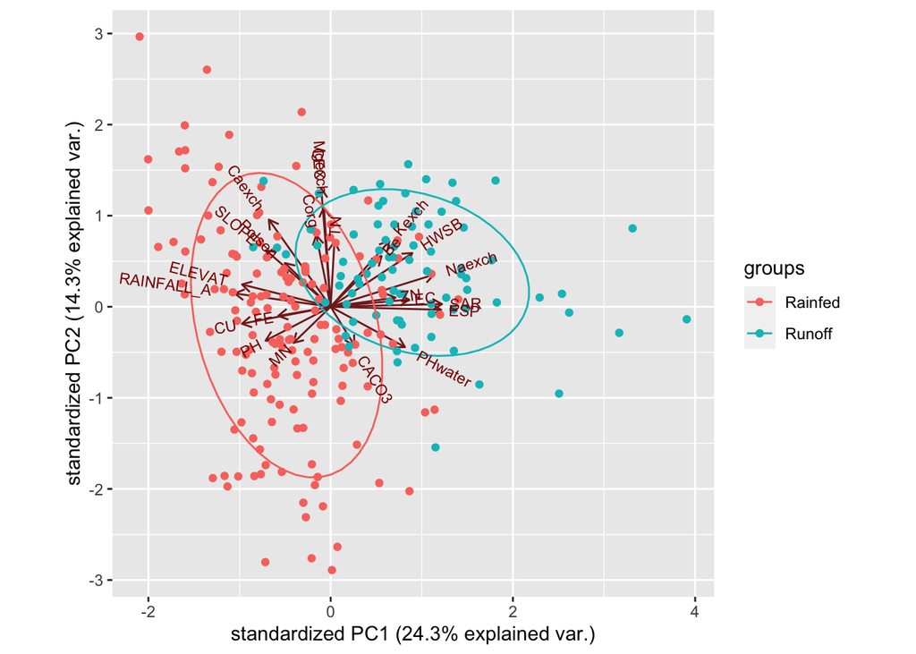

```r
ggbiplot(SoilData.pca2, ellipse=TRUE, groups = SoilData_pca1filterall$SUBCLASS4_IRRIGATION)
```

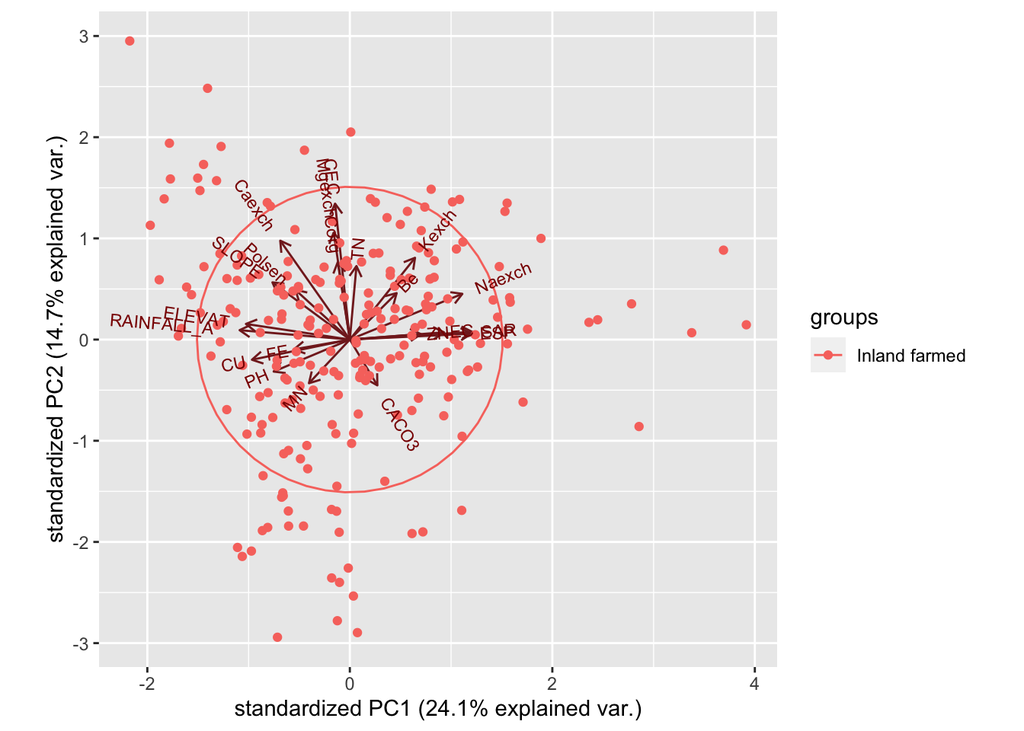

```r
SoilData_pca1filterall2 <- Remove_NA_lines(SoilData, c(14,15,17:31,33,37:39))

SoilData.pca1position2 <- prcomp(SoilData_pca1filterall2[,c(14,15,17:31,33,37:39)], center=TRUE, scale.=TRUE)

ggbiplot(SoilData.pca1position2, ellipse=TRUE, groups = SoilData_pca1filterall2$SUBCLASS5_POSITION)
```